# Loan Data from Prosper (Exploratory Data Analysis)

By Toufik Kannab

### Introduction:

Prosper is a peer-to-peer lending platform, with over $10 billion in funded loans, where individuals can either invest in personal loans or request to borrow money. On Prosper, borrowers list loan requests between $2,000 and $35,000 and individual investors invest as little as $25 in each loan listing they select. Prosper handles the servicing of the loan on behalf of the matched borrowers and investors. Prosper Marketplace is backed by leading investors including Sequoia Capital, Francisco Partners, Institutional Venture Partners, and Credit Suisse NEXT Fund.

This report will explore a loan dataset containing 113,937 loans with 81 variables on each loan, including loan amount, borrower rate (or interest rate), current loan status, borrower income, borrower employment status, borrower credit history, the latest payment information and many others.

- To download the dataset documentation, please click [here](https://docs.google.com/spreadsheets/d/1gDyi_L4UvIrLTEC6Wri5nbaMmkGmLQBk-Yx3z0XDEtI/edit#gid=0)
- To download the dataset, please click [here](https://s3.amazonaws.com/udacity-hosted-downloads/ud651/prosperLoanData.csv).
- To view the code, please click [here](https://github.com/tkannab/Udacity-DAND-T2-P2-EDA/blob/master/Loan%20Dataset%20EDA.rmd)

# Univariate Plots Section

For the purpose of this project and after reviewing the 81 variables, the analysis will be limited to the following variables:

```
##  [1] "ListingKey"                "ListingCreationDate"
##  [3] "Term"                      "LoanStatus"
##  [5] "BorrowerRate"              "ProsperRating..numeric."
##  [7] "ProsperRating..Alpha."     "ProsperScore"
##  [9] "ListingCategory..numeric." "BorrowerState"
## [11] "Occupation"                "EmploymentStatus"
## [13] "IsBorrowerHomeowner"       "CreditScoreRangeLower"
## [15] "CreditScoreRangeUpper"     "IncomeVerifiable"
## [17] "AvailableBankcardCredit"   "DebtToIncomeRatio"
## [19] "LoanKey"                   "MemberKey"
## [21] "IncomeRange"               "LoanOriginalAmount"
## [23] "Investors"
```

#### Preliminary Exploration:

As we start our exploration, we will check for missing and duplicated data as applicable.

#### 1. Dataset Keys

I reviewed the dataset structure and the variable definitions and found 4 key-related variables: `ListingKey`, `GroupKey`, `LoanKey`, and `MemberKey`; while `GroupKey` and `MemberKey` seem to have a distinct purpose and definition, `ListingKey` and `LoanKey` have a similar definition, so let’s check if there are any listings where `ListingKey` and `LoanKey` match:

```
##  [1] ListingKey                ListingCreationDate
##  [3] Term                      LoanStatus
##  [5] BorrowerRate              ProsperRating..numeric.
##  [7] ProsperRating..Alpha.     ProsperScore
##  [9] ListingCategory..numeric. BorrowerState
## [11] Occupation                EmploymentStatus
## [13] IsBorrowerHomeowner       CreditScoreRangeLower
## [15] CreditScoreRangeUpper     IncomeVerifiable
## [17] AvailableBankcardCredit   DebtToIncomeRatio
## [19] LoanKey                   MemberKey
## [21] IncomeRange               LoanOriginalAmount
## [23] Investors
## <0 rows> (or 0-length row.names)
```

Based on the output above, `ListingKey` and `LoanKey` have different values, but before determining which one to use, let’s check for *NA* empty values and duplication.

```
## No. of NA or empty values found in the variable (ListingKey): 0
```

```
## No. of NA or empty values found in the variable (LoanKey): 0
```

```
## No. of duplicate values found in the variable (ListingKey): 827
```

```
## No. of duplicate values found in the variable (LoanKey): 827
```

According to the definitions provided with the dataset, both `ListingKey` and `LoanKey` should be unique, however, as per the output above, I found a total of 827 duplicates; after isolating and reviewing duplicated rows, I found that for each duplicated key, all the other variables have duplicated values (including `LoanKey`) except for `ProsperScore`. For the purpose of this project, I will exclude them from the dataset.

#### 2. Member Keys

Looking at the variable definition, Member keys are not necessarily unique, but let’s check if there are any duplicate borrowers (borrowers who have more than one loan in the database):

```
## No. of duplicate values found in the variable (MemberKey): 0
```

As per the output above, it looks like `MemberKey` doesn’t have duplicate values.

#### 3. Loans Creation Date

For the purpose of this project, I will create a new variable called `LoanCreationYear` based on `ListingCreationDate`. Let’s plot the listings per the new variable to see the listings distribution by year.

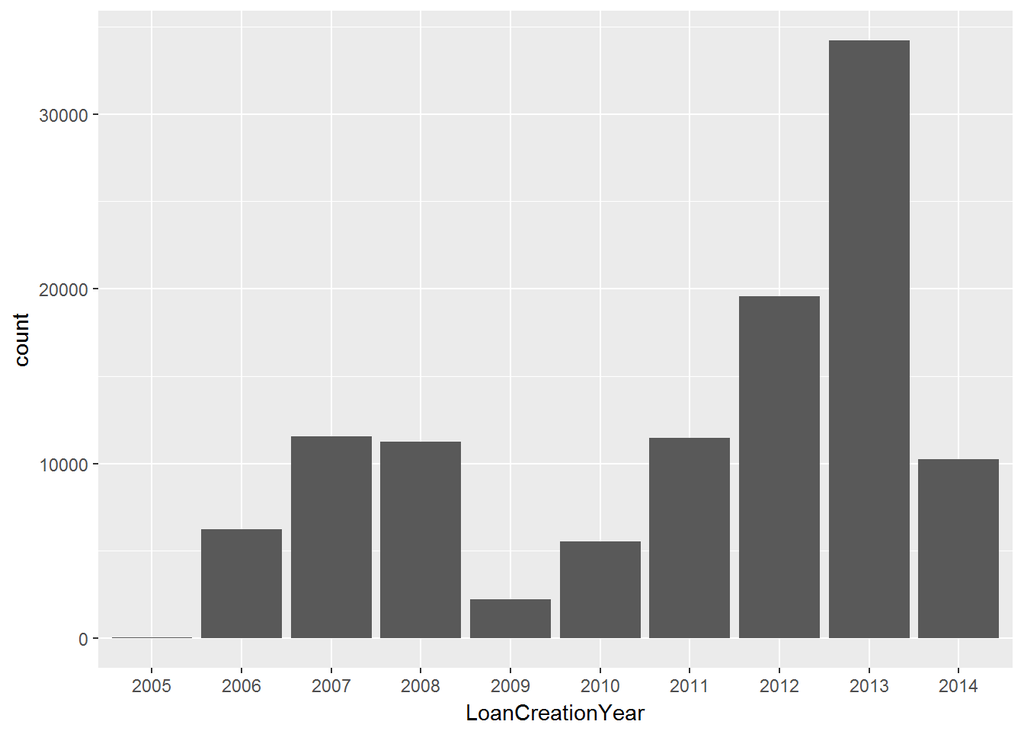

Looking at the plot above, we notice that the loan dataset spans between 2005 and 2014. Moreover, we also notice that the number of loans prior to 2010 is significantly less than 2010 - 2014. Also, from the dataset documentation, we notice there are a number of variabes **ONLY** applicable to loans created after **July 13, 2009**, including: `ProsperRating (numeric)`, `ProsperRating (Alpha)`, `ProsperScore`, and since I’m planning to use these variables later in my analysis, I will exclude the loans created prior to *July 13, 2009* to avoid *NA* or missing values. Let’s re-plot the chart above after excluding the listings (loans) created prior to **July 13, 2009**:

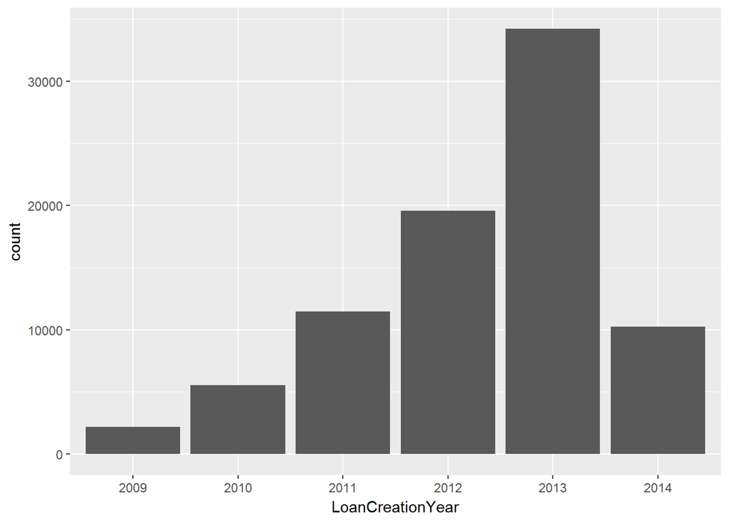

```
## [1] 83155
```

After excluding the loans, we are left with **83,155** loans which is a reasonable number to perform the analysis.

#### 4. Loan Term:

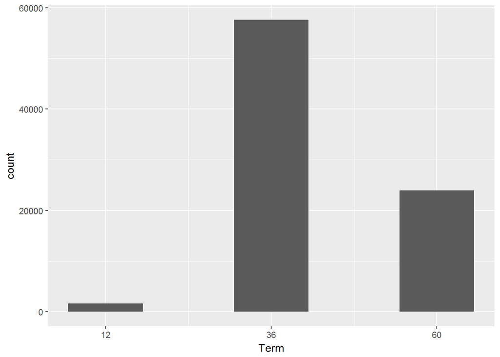

```
## # A tibble: 3 x 3
##    Term     n   freq
##   <int> <int>  <dbl>
## 1    36 57611 0.693
## 2    60 23931 0.288
## 3    12  1613 0.0194
```

Looking at the output abvove, we notice the majority of the loans (69.3%) have a 36-month term duration, where (29%) have a 60-month duration, and only about (2%) have a 12-month duration.

#### 5. LoanStatus:

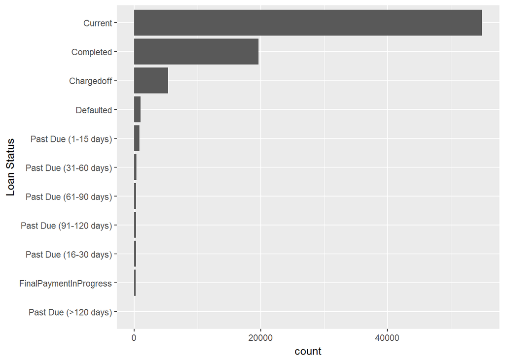

```
## # A tibble: 11 x 3
##    LoanStatus                 n     freq
##    <fct>                  <int>    <dbl>
##  1 Current                54928 0.661
##  2 Completed              19638 0.236
##  3 Chargedoff              5336 0.0642
##  4 Defaulted               1005 0.0121
##  5 Past Due (1-15 days)     794 0.00955
##  6 Past Due (31-60 days)    359 0.00432
##  7 Past Due (61-90 days)    309 0.00372
##  8 Past Due (91-120 days)   304 0.00366
##  9 Past Due (16-30 days)    265 0.00319
## 10 FinalPaymentInProgress   201 0.00242
## 11 Past Due (>120 days)      16 0.000192
```

Looking at the output above, we notice around (66%) of the loans have an active status or *Current*, (23.6%) are *Completed*, (6.4%) are *Chargedoff* and only (1.2%) are *Defaulted*. Since **Loan Delinquency** (`LoanStatus`) will play a major role in this analysis, I thought it might be useful to spend some time understanding the different categories within this variable, more specifically: Defaulted, ChargedOff and PastDue; below is a summary of the information I’ve gathered:

- **Loan Delinquency**: it is a situation in which a borrower misses its due date for a single scheduled payment for a form of financing, like student loans, mortgages, credit card balances or automobile loans. Delinquency occurs *as soon as* a borrower misses a payment. [Investopedia](https://www.investopedia.com/terms/d/delinquent.asp)
- **Default Loan**: the failure to pay interest or principal on a loan or security when due. Default occurs when a debtor is unable to meet the legal obligation of debt repayment, and it also refers to cases in which one party fails to perform on a futures contract as required by an exchange. [Investopedia](https://www.investopedia.com/terms/d/default2.asp)
- **Charge-off**: A charge-off is a debt, (e.g. a credit card), that is deemed unlikely to be collected by the creditor because the borrower has become substantially delinquent after a period of time. However, a charge-off does not mean a write-off of the debt entirely. A charge-off usually occurs when the creditor has deemed an outstanding debt is *uncollectible*; this typically follows **180 days** or six months of non-payment. In addition, debt payments that fall below the required minimum payment for the period will also be charged off if the debtor does not make up for the shortfall. The creditor crosses off the consumer’s debt as uncollectible and marks it on the consumer’s credit report as a charge-off. [Investopedia](https://www.investopedia.com/terms/c/chargeoff.asp#ixzz5AP5geIRh).

According to federal regulations, installment loans (like student loans) must be charged-off after being delinquent for 120, while revolving credit accounts (i.e, credit cards) must be charged-off after they’ve been delinquent for 180 days. [BadCredit.org](http://www.badcredit.org/delinquencies-defaults-charge-offs-whats-difference/)

**Delinquency vs. Default**: Delinquency and default are both loan terms representing different degrees of the same problem: missing payments. A loan becomes delinquent when you make payments late **(even by one day)** or miss a regular installment payment or payments. On the other hand, Loan default is much more serious, changing the nature of your borrowing relationship with the lender, and with other potential lenders as well. [Investopedia](https://www.investopedia.com/ask/answers/062315/what-are-differences-between-delinquency-and-default.asp)

Looking at the variable `LoanStatus`, although there is no category called *Delinquent*, we can identify which loands are delinquent based on the assumption that **ANY** delay will be considered a **Delinquency**, by definition. To achieve that, I created a new variable called `DelinquentList` which takes one of the following values:

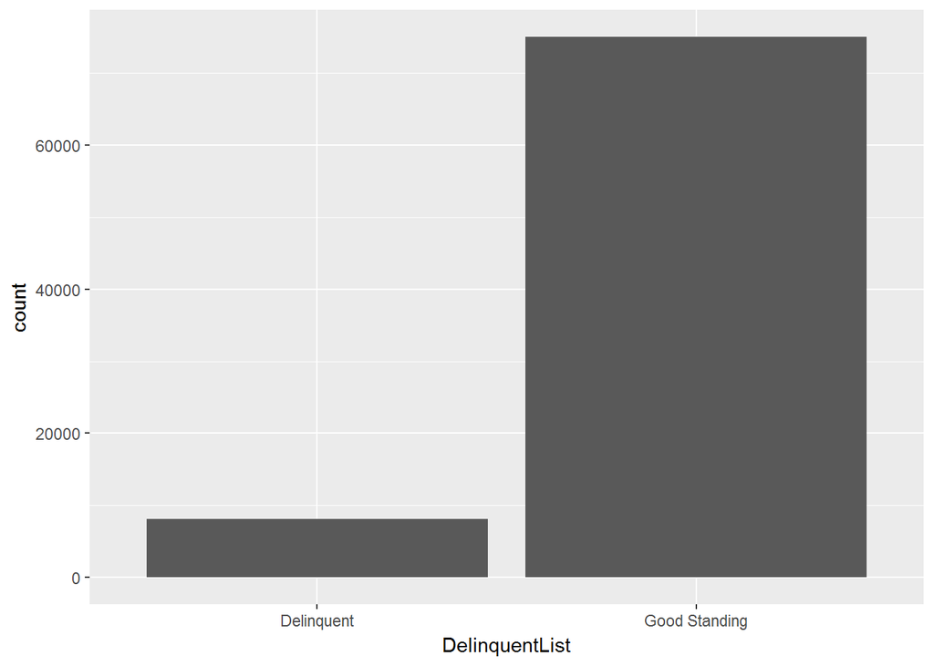

```
## # A tibble: 2 x 3
##   DelinquentList     n   freq
##   <chr>          <int>  <dbl>
## 1 Good Standing  75032 0.902
## 2 Delinquent      8123 0.0977
```

Looking at the output above, we notice the greatest majority of loans (90.23%) are in *Good Standing* status where (9.77%) are *Delinquent*. Later on, we will use the new variable `DelinquentList` to break down other variables and identify any possible correlations between those variables and loan delinquency.

#### 6. Borrower Rate

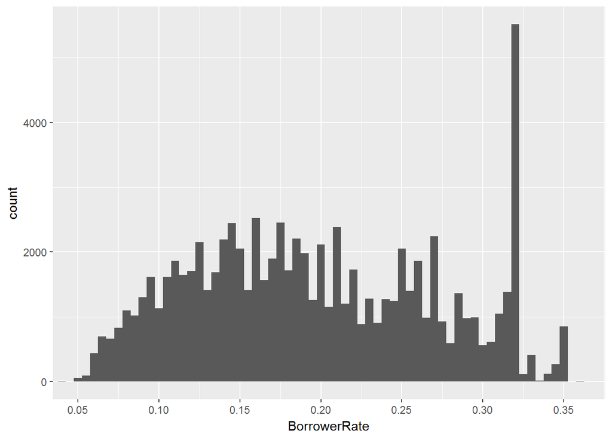

```
##      Min.   1st Qu.    Median      Mean   3rd Qu.      Max.  Std. Dev
## 0.0400000 0.1359000 0.1897000 0.1965692 0.2579000 0.3600000 0.0700000
```

```
## # A tibble: 10 x 3
##    BorrowerRate     n    freq
##           <dbl> <int>   <dbl>
##  1        0.318  3672 0.0442
##  2        0.320  1645 0.0198
##  3        0.270  1304 0.0157
##  4        0.110   890 0.0107
##  5        0.350   802 0.00964
##  6        0.210   760 0.00914
##  7        0.260   750 0.00902
##  8        0.158   742 0.00892
##  9        0.130   730 0.00878
## 10        0.220   729 0.00877
```

#### 7. Prosper Rating

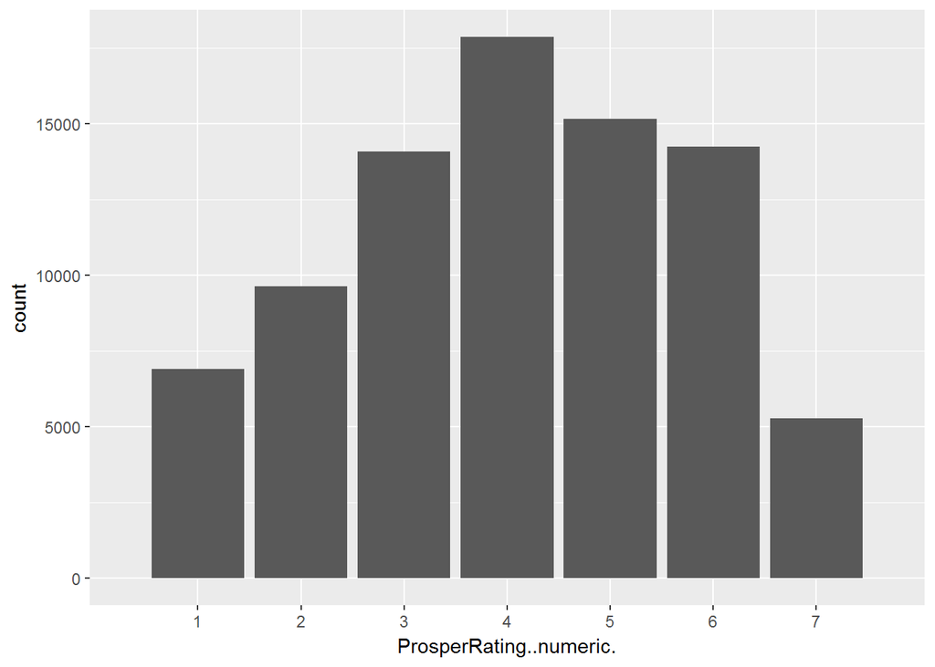

```
## # A tibble: 7 x 3
##   ProsperRating..numeric.     n   freq
##                     <int> <int>  <dbl>
## 1                       1  6901 0.0830
## 2                       2  9639 0.116
## 3                       3 14070 0.169
## 4                       4 17862 0.215
## 5                       5 15166 0.182
## 6                       6 14237 0.171
## 7                       7  5280 0.0635
```

According to the definition, `ProsperRating (numeric)` is a rating assigned at the time the listing was created: 0 - N/A, 1 - HR, 2 - E, 3 - D, 4 - C, 5 - B, 6 - A, 7 - AA. However, the definition doesn’t provide sufficient information as to what this rating actually represents or how it is calcuated/determined. As we progress, we will try to identify any possible correlations between this rating and the other variables.

#### 8. Prosper Score

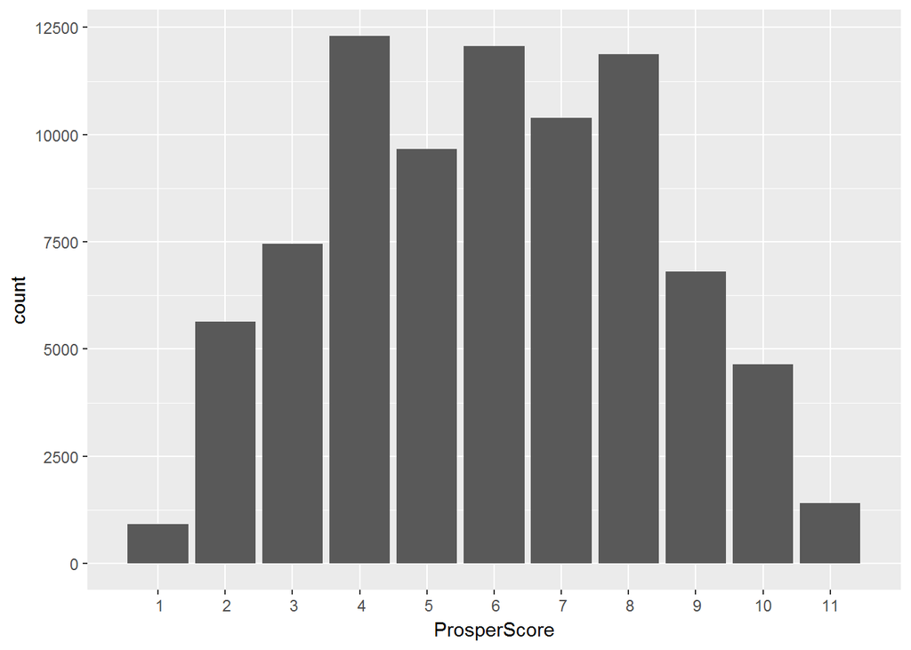

```
## # A tibble: 11 x 3
##    ProsperScore     n   freq
##           <dbl> <int>  <dbl>
##  1           1.   917 0.0110
##  2           2.  5632 0.0677
##  3           3.  7456 0.0897
##  4           4. 12300 0.148
##  5           5.  9661 0.116
##  6           6. 12064 0.145
##  7           7. 10392 0.125
##  8           8. 11875 0.143
##  9           9.  6813 0.0819
## 10          10.  4637 0.0558
## 11          11.  1408 0.0169
```

Looking at the output above, the distribution looks relatively normal; the top 3 proportions of loans have received a score of 4, 6 and 8 respectively.

According to the definition, `ProsperScore` is a custom risk score built using historical Prosper data. The score ranges from 1-10, with 10 being the best, or lowest risk score. However, the output above shows (1,408) loans with a score of 11. For the purpose of this project and after reviewing the documentation, I will replace the 11’s with the mean value of `ProsperScore` which is 6 (the mean is 5.9, I will round it up to 6). After replacing the errored values, let’s check the values again:

```
## # A tibble: 10 x 3
##    ProsperScore     n   freq
##           <dbl> <int>  <dbl>
##  1           1.   917 0.0110
##  2           2.  5632 0.0677
##  3           3.  7456 0.0897
##  4           4. 12300 0.148
##  5           5.  9661 0.116
##  6           6. 13472 0.162
##  7           7. 10392 0.125
##  8           8. 11875 0.143
##  9           9.  6813 0.0819
## 10          10.  4637 0.0558
```

#### 8. Listing Category:

Per review of the definition and the values asssigned to variable `ListingCategory..numeric.`, I will create a new variable called `NewListingCategory` to include the actual categories.

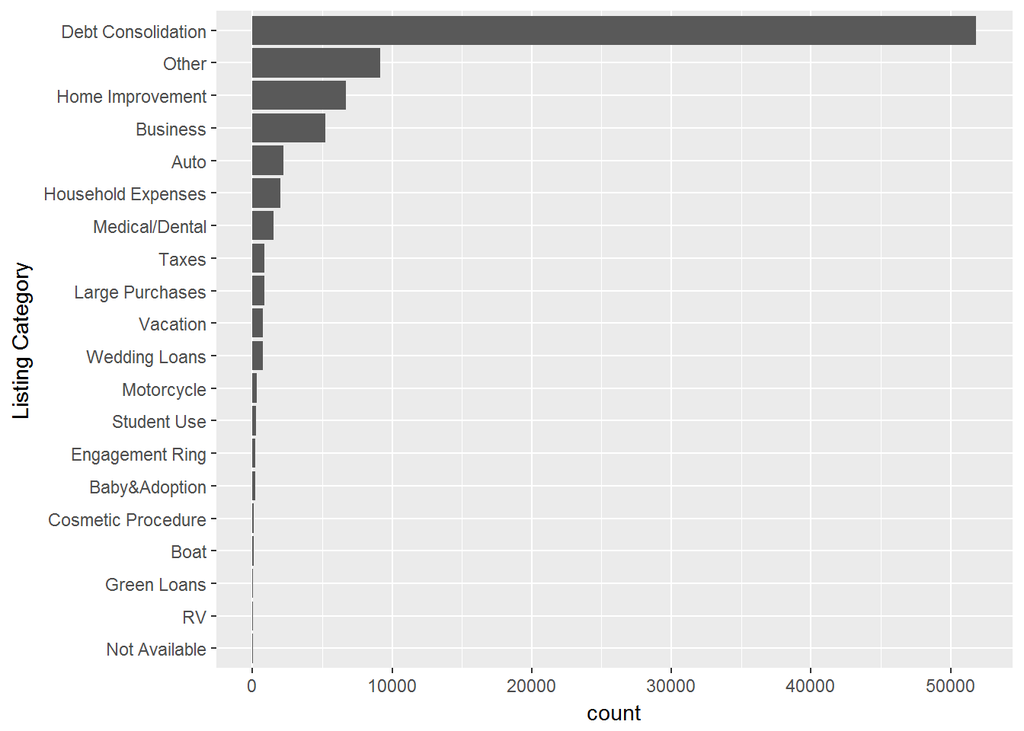

```
## # A tibble: 20 x 3
##    NewListingCategory     n     freq
##    <chr>              <int>    <dbl>
##  1 Debt Consolidation 51849 0.624
##  2 Other               9127 0.110
##  3 Home Improvement    6713 0.0807
##  4 Business            5236 0.0630
##  5 Auto                2229 0.0268
##  6 Household Expenses  1978 0.0238
##  7 Medical/Dental      1493 0.0180
##  8 Taxes                879 0.0106
##  9 Large Purchases      851 0.0102
## 10 Vacation             760 0.00914
## 11 Wedding Loans        753 0.00906
## 12 Motorcycle           304 0.00366
## 13 Student Use          274 0.00330
## 14 Engagement Ring      211 0.00254
## 15 Baby&Adoption        193 0.00232
## 16 Cosmetic Procedure    91 0.00109
## 17 Boat                  85 0.00102
## 18 Green Loans           57 0.000685
## 19 RV                    52 0.000625
## 20 Not Available         20 0.000241
```

Looking at the output above, we notice the largest category (62.24%) is *Debit Consolidation*, where the smallest category is *Not Available* with only 20 loans.

#### 9. BorrowerState:

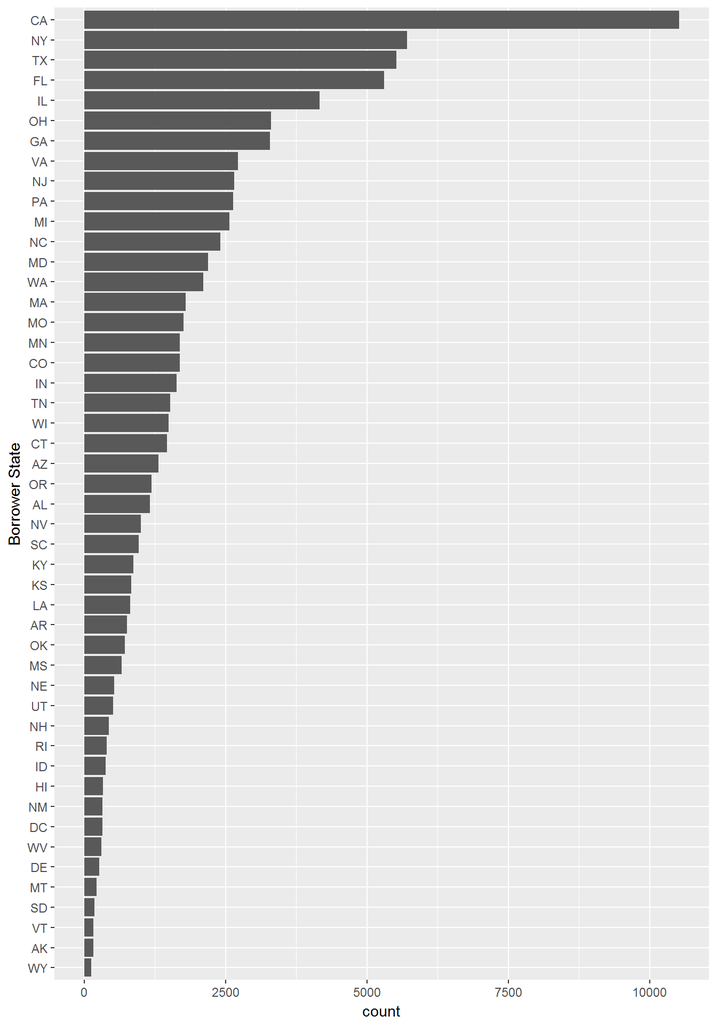

```
## # A tibble: 10 x 3
##    BorrowerState     n   freq
##    <fct>         <int>  <dbl>
##  1 CA            10524 0.127
##  2 NY             5709 0.0687
##  3 TX             5523 0.0664
##  4 FL             5302 0.0638
##  5 IL             4168 0.0501
##  6 OH             3308 0.0398
##  7 GA             3284 0.0395
##  8 VA             2725 0.0328
##  9 NJ             2657 0.0320
## 10 PA             2634 0.0317
```

Looking at the output above, we notice there are loans from the 48 states, as expected, the state with the largest proportion (12.66%) is *California*, where the state with the smallest proportion is *Wyoming* with 123 loans.

#### 10. Occupation:

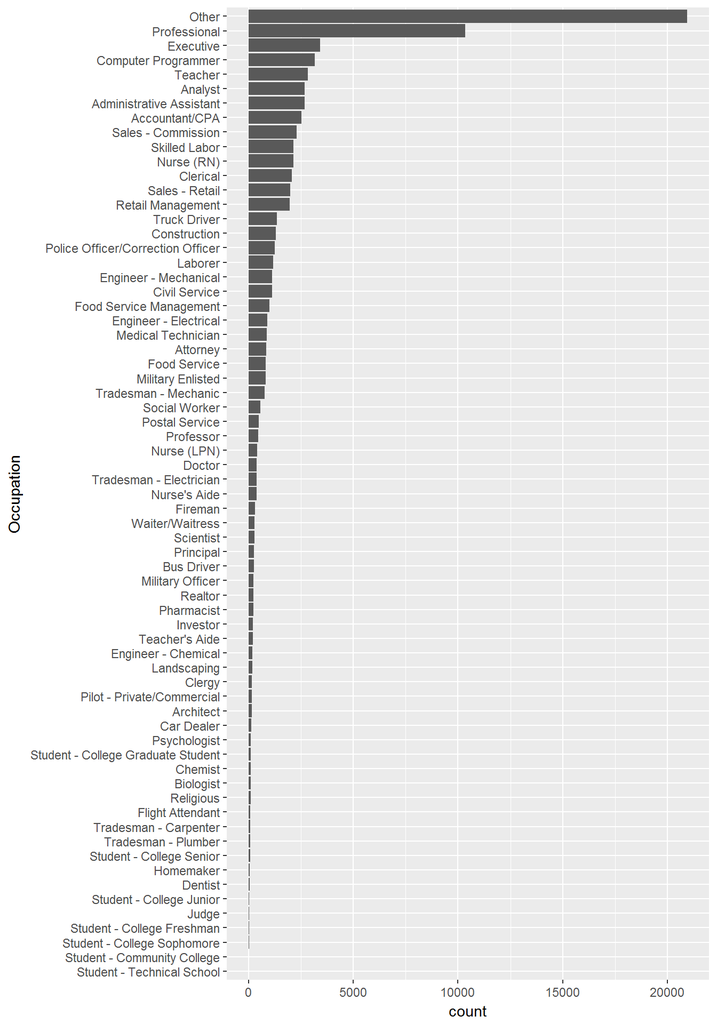

```
## # A tibble: 10 x 3
##    Occupation                   n   freq
##    <fct>                    <int>  <dbl>
##  1 Other                    20942 0.252
##  2 Professional             10354 0.125
##  3 Executive                 3407 0.0410
##  4 Computer Programmer       3165 0.0381
##  5 Teacher                   2828 0.0340
##  6 Analyst                   2687 0.0323
##  7 Administrative Assistant  2686 0.0323
##  8 Accountant/CPA            2526 0.0304
##  9 Sales - Commission        2288 0.0275
## 10 Skilled Labor             2134 0.0257
```

```
## No. of NA or empty values in the variable (Occupation): 1218
```

#### 11. Employement Status:

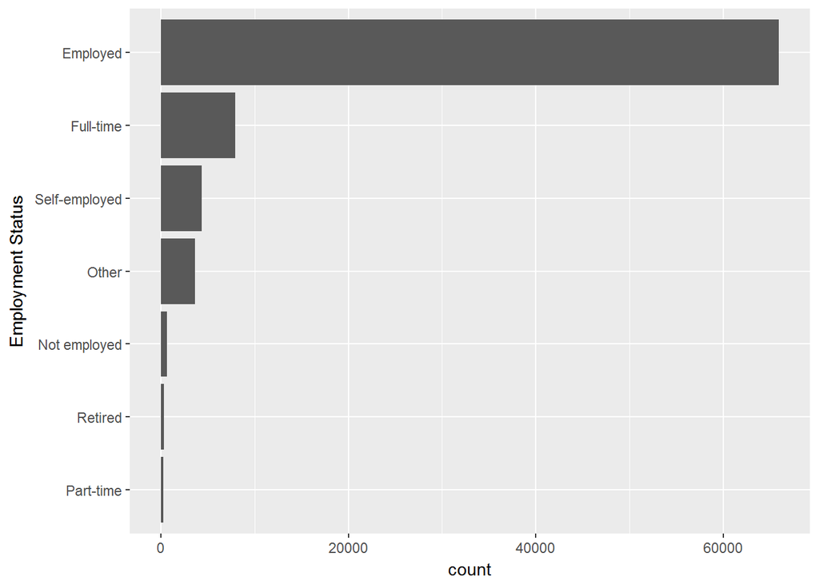

```
## # A tibble: 7 x 3
##   EmploymentStatus     n    freq
##   <fct>            <int>   <dbl>
## 1 Employed         65900 0.792
## 2 Full-time         7925 0.0953
## 3 Self-employed     4377 0.0526
## 4 Other             3681 0.0443
## 5 Not employed       649 0.00780
## 6 Retired            367 0.00441
## 7 Part-time          256 0.00308
```

Looking at the output above, the largest proportion of borrowers (79.25%) are *Employed* where only (0.3%) have a *Part-time* job.

#### 12. Home Owners:

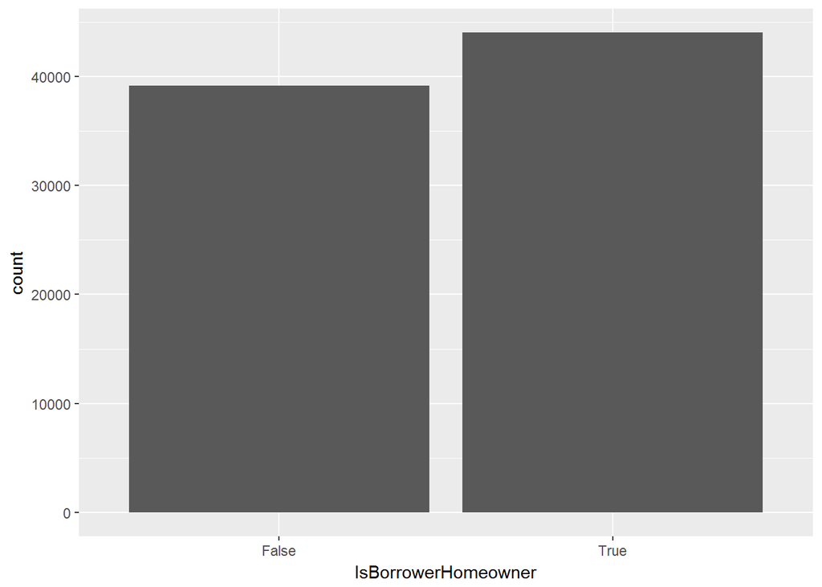

```
## # A tibble: 2 x 3
##   IsBorrowerHomeowner     n  freq
##   <fct>               <int> <dbl>
## 1 True                44014 0.529
## 2 False               39141 0.471
```

Looking at the output above, we notice that about 53% of the borrowers are home owners.

#### 13. Average Credit Score:

To analyze the credit score, I will create a new variable called `AvgCreditScore` which is the average value of two variables: `CreditScoreRangeUpper` and `CreditScoreRangeLower`.

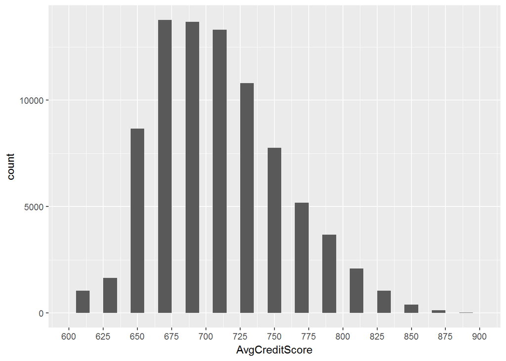

```
##     Min.  1st Qu.   Median     Mean  3rd Qu.     Max. Std. Dev
## 609.5000 669.5000 709.5000 709.0601 729.5000 889.5000  47.2700
```

```
## # A tibble: 10 x 3
##    AvgCreditScore     n   freq
##             <dbl> <int>  <dbl>
##  1           610.  1038 0.0125
##  2           630.  1653 0.0199
##  3           650.  8656 0.104
##  4           670. 13762 0.165
##  5           690. 13672 0.164
##  6           710. 13307 0.160
##  7           730. 10791 0.130
##  8           750.  7760 0.0933
##  9           770.  5176 0.0622
## 10           790.  3672 0.0442
```

Looking at the results above, The average value of the `AvgCreditScore` is (709.1) with a minimum of (609.5) and a maximum of (889.5). According to a (fico.com) blog [post](http://www.fico.com/en/blogs/risk-compliance/us-average-fico-score-hits-700-a-milestone-for-consumers/), the percentage of consumers scoring in the range (800 and up) has steadily increased since 2010 after the bottoming out of the economy between 2009 - 2010; the data presented in the post was based on a snapshot of millions of US consumers’ credit data that ranges between 2005 - 2017, the post shows how the average credit score has increased from (686) in October 2009 to (696) in October 2015, and later hit the (700) threshold by April 2017. By comparing the figures included in this post with our dataset, I can reasonably assume that our dataset is consistent with what was found in the post; I’ve also noticed, based on the histogram above, that the distribution of the average credit score is relatively normal, which is expected, with a longer right tail. Another interesting observation I’ve noticed is that there are spaces of the same size (20 points) between the bins, I’m not quite sure why this is the case, it could be related to the way credit scores are fed to the loan system, but this is something to be considered when conducting a more in-depth analysis of the credit score variables.

#### 14. Available Bank card Credit

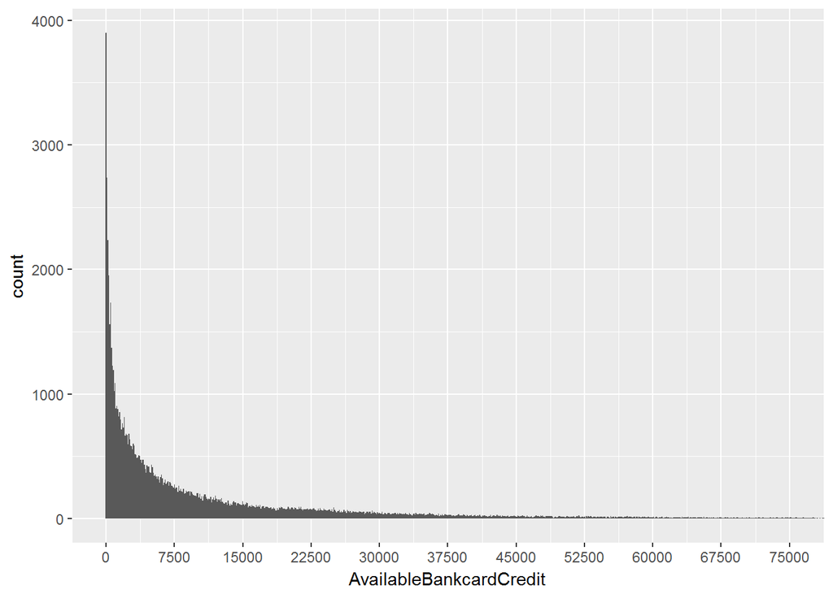

```
##      Min.   1st Qu.    Median      Mean   3rd Qu.      Max.  Std. Dev
##      0.00   1138.00   4565.00  11399.61  13900.00 498374.00  18660.96
```

```
## # A tibble: 10 x 3
##    AvailableBankcardCredit     n     freq
##                      <dbl> <int>    <dbl>
##  1                      0.  2407 0.0289
##  2                    500.   221 0.00266
##  3                    300.   101 0.00121
##  4                   1000.    98 0.00118
##  5                   2000.    89 0.00107
##  6                   3000.    75 0.000902
##  7                   1500.    72 0.000866
##  8                   2500.    63 0.000758
##  9                   5000.    55 0.000661
## 10                     76.    50 0.000601
```

Looking at the ouput above, we notice the distribution of the variable `AvailableBankcardCredit` is significantly right-skewed;

#### 15. DebtToIncomeRatio:

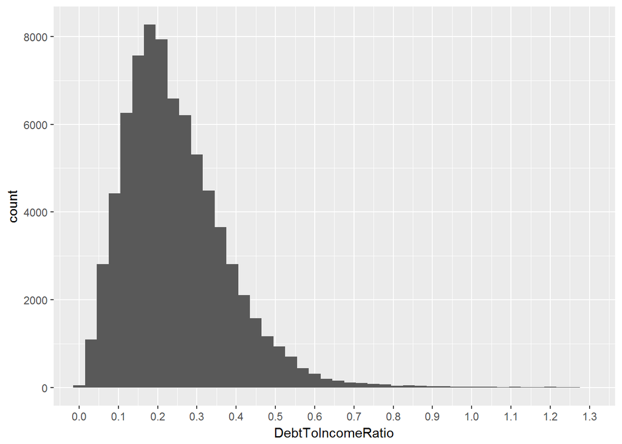

```
##         Min.      1st Qu.       Median         Mean      3rd Qu.
##    0.0000000    0.1500000    0.2200000    0.2586333    0.3200000
##         Max.         NA's     Std. Dev
##   10.0100000 7135.0000000           NA
```

```
## # A tibble: 10 x 3
##    DebtToIncomeRatio     n   freq
##                <dbl> <int>  <dbl>
##  1            NA      7135 0.0858
##  2             0.180  3156 0.0380
##  3             0.220  2950 0.0355
##  4             0.170  2707 0.0326
##  5             0.140  2662 0.0320
##  6             0.210  2512 0.0302
##  7             0.160  2502 0.0301
##  8             0.200  2477 0.0298
##  9             0.190  2405 0.0289
## 10             0.150  2400 0.0289
```

```
## No. of NA or empty values in the variable (DebtToIncomeRatio): 7135
```

Looking at the output above, the distribution of the variable `DebtToIncomeRatio` is right skewed with a mean of (25.9%). We also notice that the largest proportions (8.5%) or (7,135) loans don’t have a value for `DebtToIncomeRatio`, where (3.8%) of the loans have a `DebtToIncomeRatio` of (18%).

#### 16. Income Range:

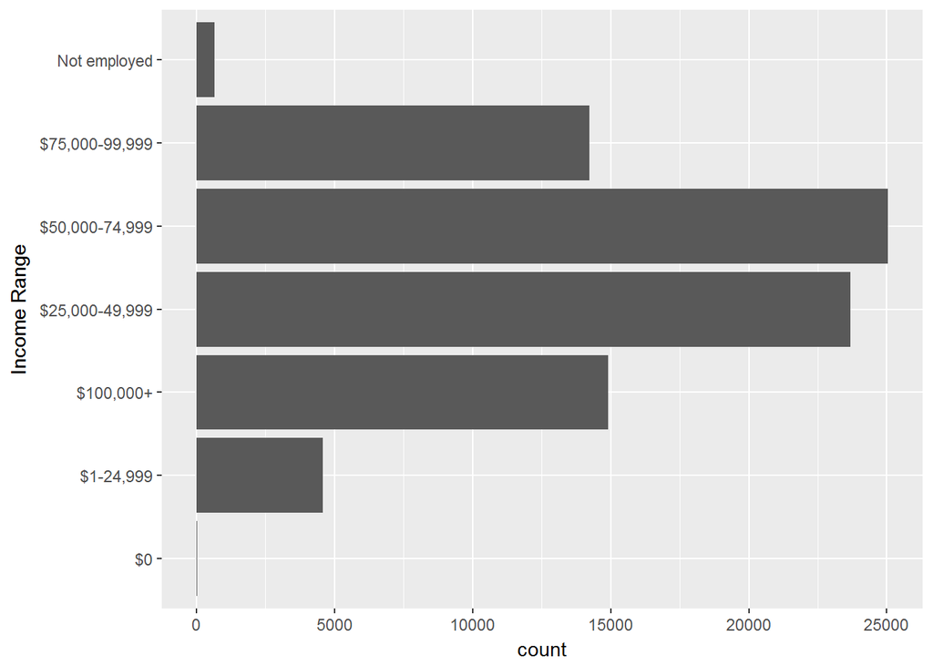

```
## # A tibble: 7 x 3
##   IncomeRange        n     freq
##   <fct>          <int>    <dbl>
## 1 $50,000-74,999 25040 0.301
## 2 $25,000-49,999 23686 0.285
## 3 $100,000+      14914 0.179
## 4 $75,000-99,999 14232 0.171
## 5 $1-24,999       4589 0.0552
## 6 Not employed     649 0.00780
## 7 $0                45 0.000541
```

#### 17. Income Verifiable:

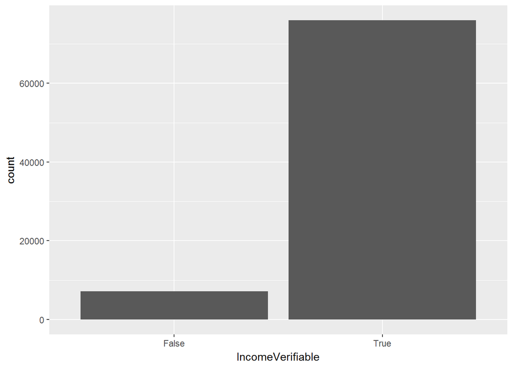

```
## # A tibble: 2 x 3
##   IncomeVerifiable     n   freq
##   <fct>            <int>  <dbl>
## 1 True             75983 0.914
## 2 False             7172 0.0862
```

Looking at the output above, we notice the majority of borrowers (91.38%) have provided income verification documents.

#### 18. Loan Original Amount:

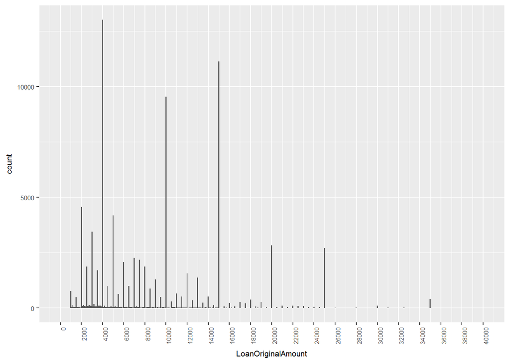

```
##    Min. 1st Qu.  Median    Mean 3rd Qu.    Max.
##    1000    4000    7500    9039   13500   35000
```

```
## # A tibble: 10 x 3
##    LoanOriginalAmount     n   freq
##                 <int> <int>  <dbl>
##  1               4000 12985 0.156
##  2              15000 11118 0.134
##  3              10000  9526 0.115
##  4               2000  4544 0.0546
##  5               5000  4152 0.0499
##  6               3000  3411 0.0410
##  7              20000  2815 0.0339
##  8              25000  2706 0.0325
##  9               7000  2254 0.0271
## 10               7500  2162 0.0260
```

Looking at the output above, the average original loan amount is ($ 9,039). To better understnad the distribution of loan amounts, I adjusted the histogram binwidth to (100). As a result, we notice there are specific loan amounts that are more common than others, for example ($ 4,000) has the highest proportion (15.6%), ($ 15,000) comes next with (13.3%); We can also see an outlier at the value $35,000.

#### 19. Investors

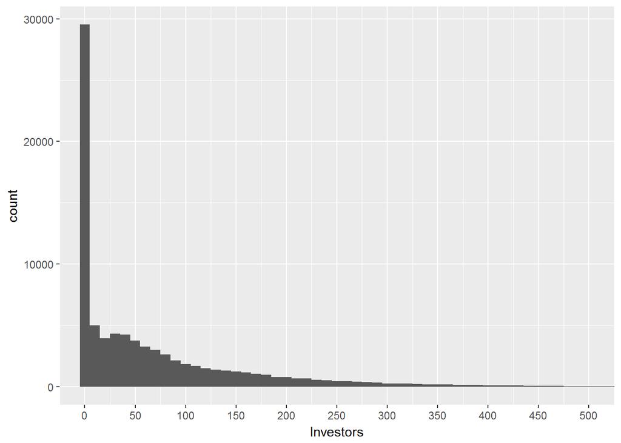

```
##    Min. 1st Qu.  Median    Mean 3rd Qu.    Max.
##    1.00    1.00   33.00   69.07   98.00 1189.00
```

```
## # A tibble: 10 x 3
##    Investors     n    freq
##        <int> <int>   <dbl>
##  1         1 26206 0.315
##  2         2  1178 0.0142
##  3         3   848 0.0102
##  4         4   686 0.00825
##  5         5   609 0.00732
##  6         8   606 0.00729
##  7         6   565 0.00679
##  8         7   542 0.00652
##  9         9   542 0.00652
## 10        10   519 0.00624
```

Looking at the output above, the average number of investors per loan is (69) investors; the largest proportion of loans (%31.5) have one investor. We also notice that the maximum number of investors for one loan is (1,189) , which is an interesting number, so I pulled up the loans with a number of investors greater than 1000 and found (2) loans with a loan original amount of ($ 25,000) and (2) loans with a loan original amount of ($ 20,000)

```
##   Investors LoanOriginalAmount
## 1      1024              25000
## 2      1035              25000
## 3      1011              20000
## 4      1189              20000
```

# Univariate Analysis

### What is the structure of your dataset?

The dataset includes 113,937 observations and 81 variables. After excluding loans with duplicate keys and loans created pior to July 13, 2009, the new number of loans is 83,155.

### What is/are the main feature(s) of interest in your dataset?

There are two main features to be investigated:

1. **Loan Delinquency**: I’m interested in analyzing how other variables contribute to the loan delinquency rate. This analysis will provide some guidance on the contributing factors to loan delinquency and ultimately help investors select investments with a reasonable risk/return ratio. In order to do that, I created a new variable `DelinquentList` based on the variable `LoanStatus` and the information collected from the external references included above.
2. **Interest Rate**: Here, I’m interested in analyzing the contributing factors to the loan interest rate and ultimately provide some guidance to help borrowers make more informative decisions when applying for loans.

### What other features in the dataset do you think will help support your investigation into your feature(s) of interest?

To perform my analysis, I’ve limited the dataset to the following variables:

“ListingKey”, “ListingCreationDate”, “Term”, “LoanStatus”, “BorrowerRate”, “ProsperRating..numeric.”, “ProsperRating..Alpha.”, “ProsperScore”,“ListingCategory..numeric.”,“BorrowerState”, “Occupation”, “EmploymentStatus”, “IsBorrowerHomeowner”, “CreditScoreRangeLower”, “CreditScoreRangeUpper”, “IncomeVerifiable”,“AvailableBankcardCredit”, “DebtToIncomeRatio”, “LoanKey”, “MemberKey”,“IncomeRange”, “LoanOriginalAmount”,“Investors”

### Did you create any new variables from existing variables in the dataset?

Yes, as I mentioned above, I created the following variables: `LoanCreationYear`, `DelinquentList`, `AvgCreditScore`, `NewListingCategory`

I also created a new function `mySummary` to add standard deviation to the output of the built-in `summary` function.

### Of the features you investigated, were there any unusual distributions? Did you perform any operations on the data to tidy, adjust, or change the form of the data? If so, why did you do this?

The dataset is well-structured, therefore, I haven’t performed any major operations to adjust the structure, however, I’ve made a number of minor formatting changes. For example, I changed the format of `ListingCreationDate` from character to DateTime.

Also, I updated the `ProserScore` column to replace 11’s with 6’s (the mean score) as the score takes values between 1 to 10, per the definition.

As far as unusual distributions, I found the following: - `AvailableBankcardCredit` is significantly right-skewed. - `DebtToIncomeRatio` is right skewed. - `LoanOriginalAmount` is relatively right-skewed with a good proportion of outliers. - `Investors` is significantly right-skewed.

I also found some interesting Data Peaks & valleys. For example:

- `Term`: (70%) of the loans have a 36 month term duration.
- `DelinquentList`: (90%) of the loans have a *Good Standing* status, which indicates a healthy economy.
- `BorrowerRate:`: (4.4 %) of the loans have an interest rate of (31.8 %) which can be considered high when compared to the mean (19.6%).
- `ListingCategory`: (62.4%) of the loans reported *Debit Consolidation*.
- `BorrowerState`: (12.7%) of the loans belong to borrowers from *California*.
- `Occupation`: (25%) reported *Other* as an Occupation.

As far as missing values, I identified the following:

- `DebtToIncomeRatio`: I’ve found 7,135 missing value which seems unusual. Unfortunately, there is no further explanation provided in the dataset documentation as to why these values are missing. While it might be on option to populate the missing rows with a *calcuated* DebtToIncomeRatio using the available debt and income information in the dataset, it wouldn’t be easy to determine the total amount of debt since borrowers might have other loans with different financial institutions not included in the dataset, so it won’t be an efficient choice, and therefore I excluded those loans from the dataset.
- `Occupation`: we found 1,218 missing values.

# Bivariate Plots Section

In this section, I will mainly focus on two main features: Loan Delinquency (`DelinquentList`) and Interest Rate (`BorrowerRate`), however, I may extend my analysis to include other features, as applicable,

### I. Loan Delinquency

#### 1. Loan Delinquency vs. Loan Creation Year

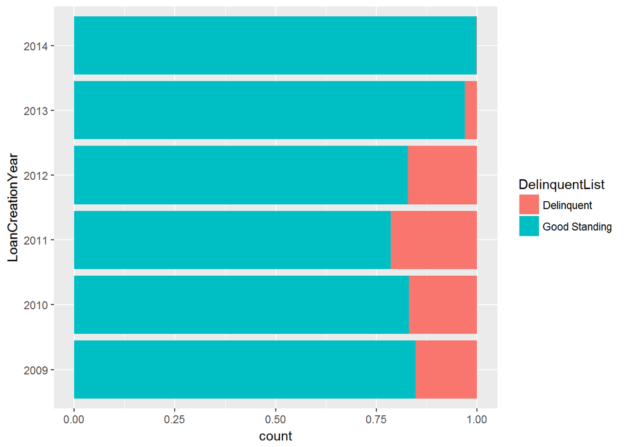

```
##      var2 Delinquent Good Standing
## var1
## 2009           15.29         84.71
## 2010           16.89         83.11
## 2011           21.39         78.61
## 2012           17.18         82.82
## 2013            3.05         96.95
## 2014            0.07         99.93
```

Looking at the output above, we notice the percentage of *Good Standing* loans has significantly increased in 2014 (99.93%) as opposed to (78.61%) in 2011.

#### 2. Loan Delinquency vs. Term

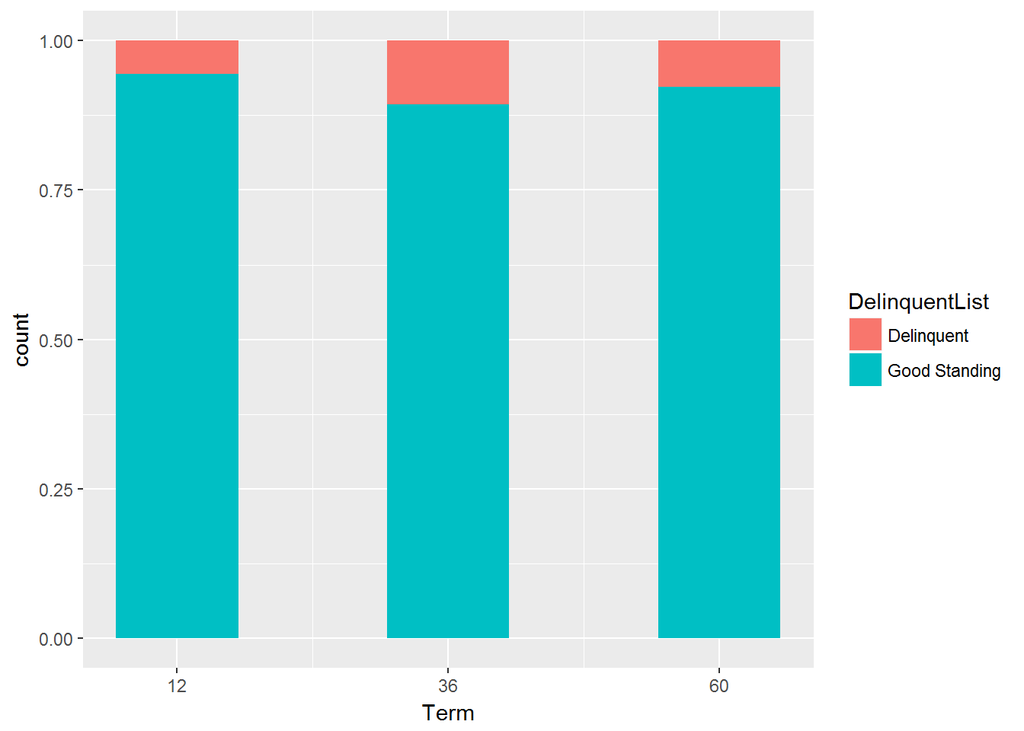

```
##      var2 Delinquent Good Standing
## var1
## 12              5.52         94.48
## 36             10.71         89.29
## 60              7.79         92.21
```

Looking at the output above, it looks like loans with 12-month duration tend to perform slightly better than loans with 36- and 60-month duations;

#### 3. Loan Delinquency vs. Borrower Rate

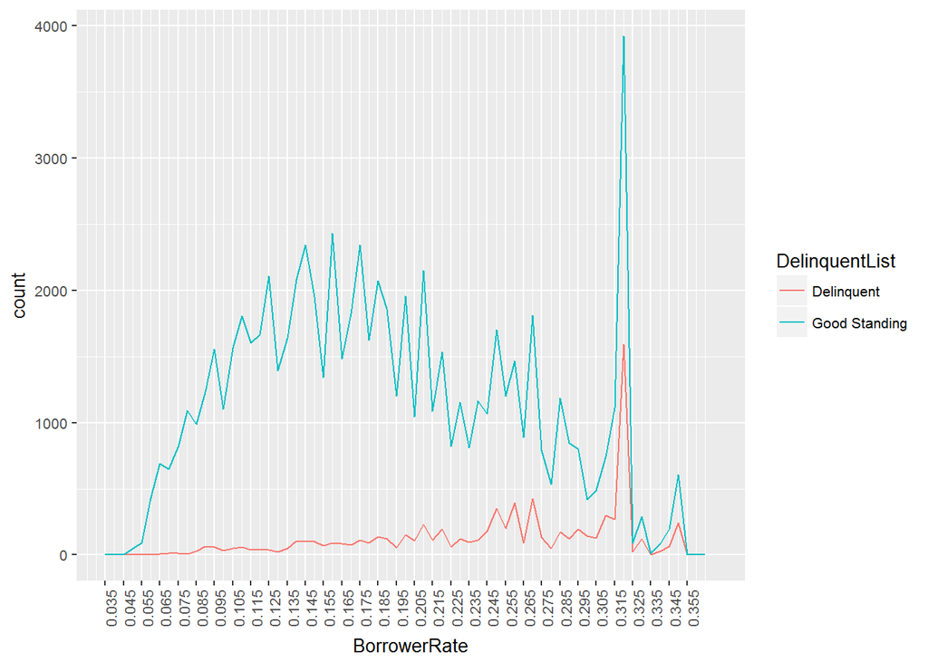

Looking at the plot above, we notice the distribution of the `BorrowerRate` for *Good standing* loans experiences more fluctuations than *Delinquent* loans; we also notice the count of both *Good standing* and *Delinquent* loans experiances a significant peak at BorrowRate = 0.31799. This is an interesting observation and can be worth further analysis.

#### 4. Loan Delinquency vs. ProsperRating

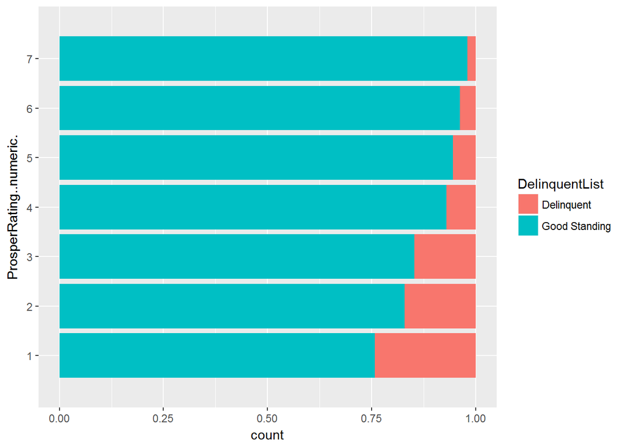

```
##      var2 Delinquent Good Standing
## var1
## 1              24.21         75.79
## 2              17.09         82.91
## 3              14.78         85.22
## 4               7.03         92.97
## 5               5.41         94.59
## 6               3.83         96.17
## 7               1.99         98.01
```

Looking at the output above, and as expected, the proportion of *Good Standing* loans increases as the ProsperRating increases (positive correlation).

#### 5. Loan Delinquency vs. Prospoer Score

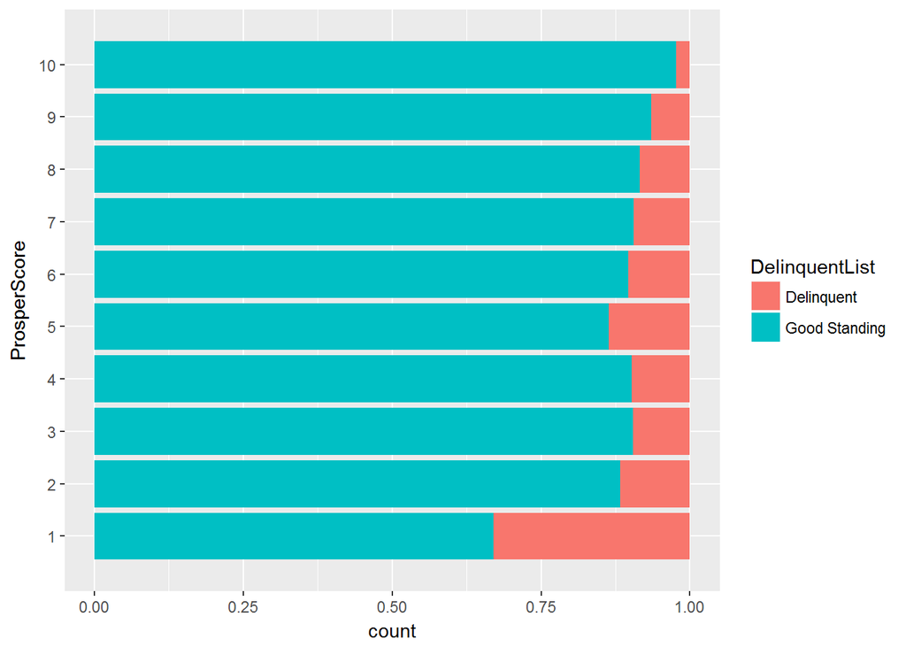

```
##      var2 Delinquent Good Standing
## var1
## 1              33.04         66.96
## 2              11.75         88.25
## 3               9.56         90.44
## 4               9.77         90.23
## 5              13.68         86.32
## 6              10.30         89.70
## 7               9.45         90.55
## 8               8.46         91.54
## 9               6.47         93.53
## 10              2.29         97.71
```

Looking at the output above; similar to what we found with `ProsperRating..numeric.`, the proportion of *Good Standing* loans increases as the `ProsperScore` increases. However, for loans with scores of 4 and 5, As the score increases, the proportion of *Good Standing* loans decreases, which leads us to think there might be another feature that could have a **stronger** impact on loan Delinquency than impact `ProsperScore` has on loan Delinquency. This is an interesting observation and can be worth further analysis.

#### 6. Loan Delinquency vs. Listing Category

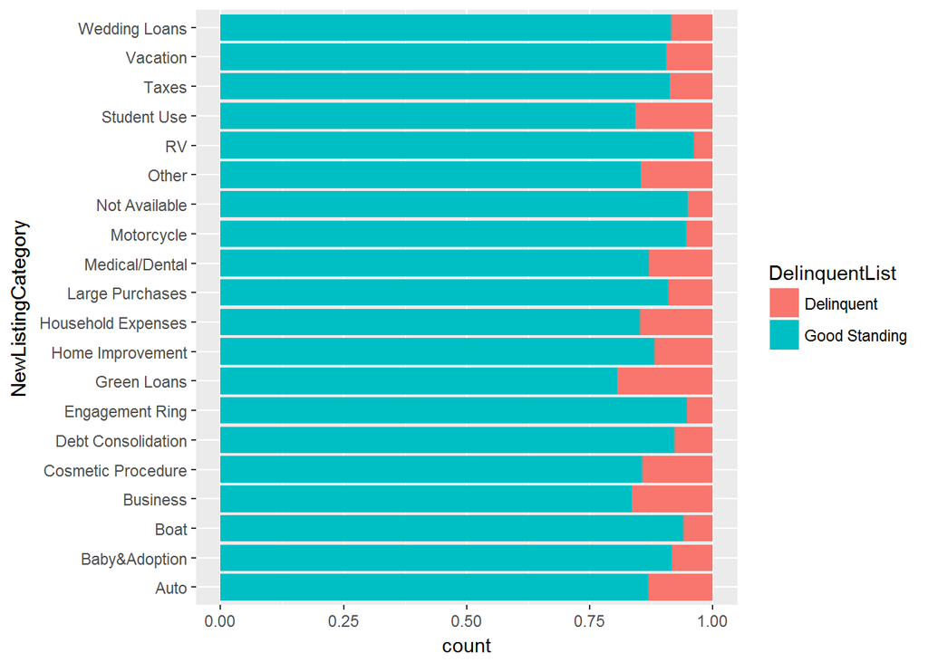

```
##                    var2 Delinquent Good Standing
## var1
## Auto                         13.01         86.99
## Baby&Adoption                 8.29         91.71
## Boat                          5.88         94.12
## Business                     16.39         83.61
## Cosmetic Procedure           14.29         85.71
## Debt Consolidation            7.65         92.35
## Engagement Ring               5.21         94.79
## Green Loans                  19.30         80.70
## Home Improvement             11.80         88.20
## Household Expenses           14.66         85.34
## Large Purchases               8.93         91.07
## Medical/Dental               12.93         87.07
## Motorcycle                    5.26         94.74
## Not Available                 5.00         95.00
## Other                        14.56         85.44
## RV                            3.85         96.15
## Student Use                  15.69         84.31
## Taxes                         8.76         91.24
## Vacation                      9.34         90.66
## Wedding Loans                 8.37         91.63
```

Looking at the output above, the category *RV* has the highest proportion (96.15%) of *Good Standing* Loans, where in *Debt Consoliation*, the percentage of good standing loans is (92.35%)

#### 7. Loan Delinquency vs. Debt-To-InCome Ratio

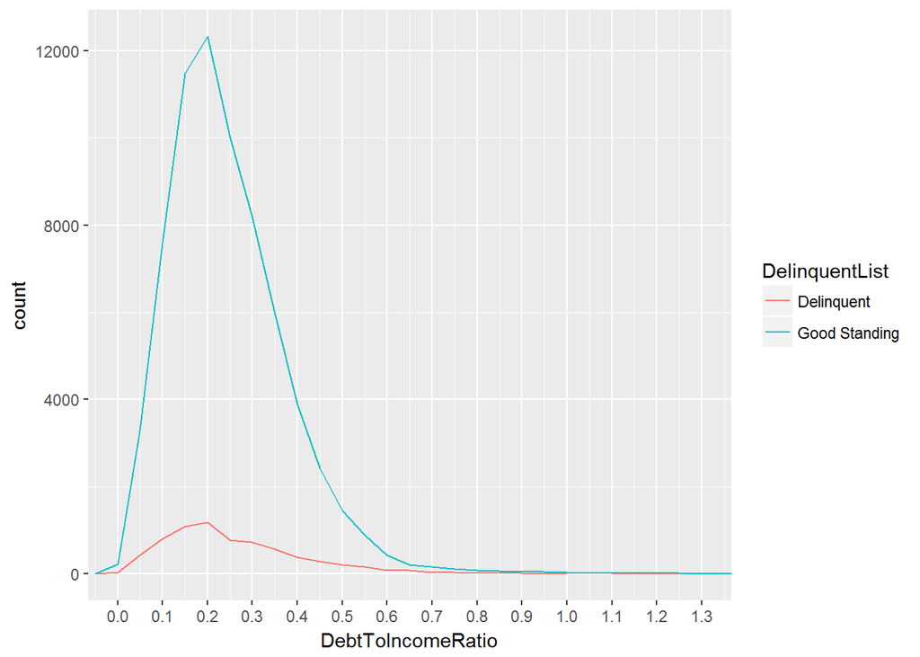

From the plot above, we notice the distributions of the `DebtToIncomeRatio` are right-skewed for both *Good Standing* and *Delinquent* loans in the range between 0 and 0.8, however, things become less clear above 0.8. To get a better understanding of the distributions above 0.8, I will transform the data using `log10()` function, as follows:

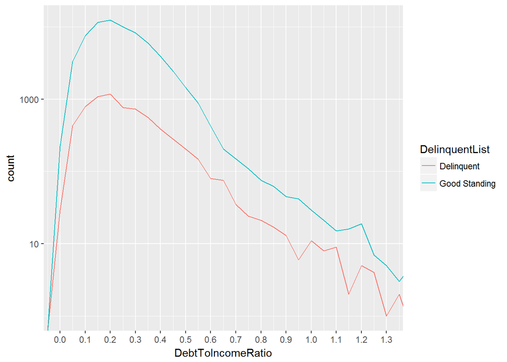

After transforming the data, we notice `DebtToIncomeRatio` has a similar behaviour for *Delinquent* and *Good standing* loans with minor fluctuations.

### II. Interest Rate (BorrowerRate)

#### 1. Interest Rate vs State

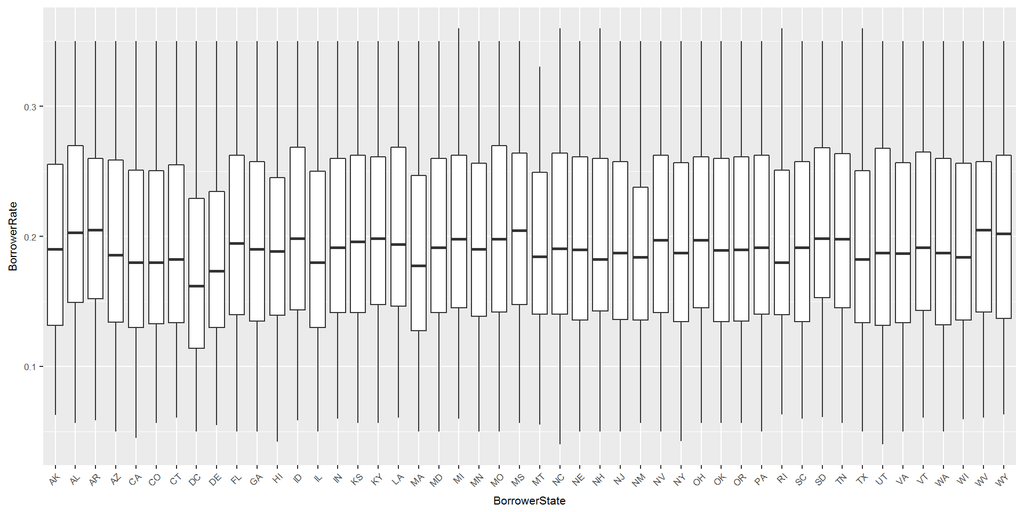

```
## # A tibble: 10 x 6
##    BorrowerState     n  mean median `25%` `75%`
##    <fct>         <int> <dbl>  <dbl> <dbl> <dbl>
##  1 AL             1165 0.209  0.203 0.149 0.270
##  2 MS              667 0.208  0.204 0.147 0.264
##  3 SD              182 0.208  0.198 0.153 0.268
##  4 AR              761 0.207  0.205 0.152 0.260
##  5 ID              385 0.205  0.198 0.144 0.268
##  6 LA              817 0.205  0.194 0.146 0.268
##  7 KY              870 0.204  0.198 0.147 0.261
##  8 TN             1518 0.204  0.198 0.145 0.264
##  9 MO             1759 0.204  0.198 0.142 0.270
## 10 MI             2572 0.204  0.198 0.145 0.262
```

Looking at the output above, we notice that Alabama (AL) has the highest average interest rate of (20.9%) where District of Columbia (DC) has the lowest average interest rate of (17.7%); I also found that California (CA), which has the highest loan proportion, has an average interest rate of (19%) which is quite close to the overall average interest rate;

#### 2. Interest Rate vs Listing Category

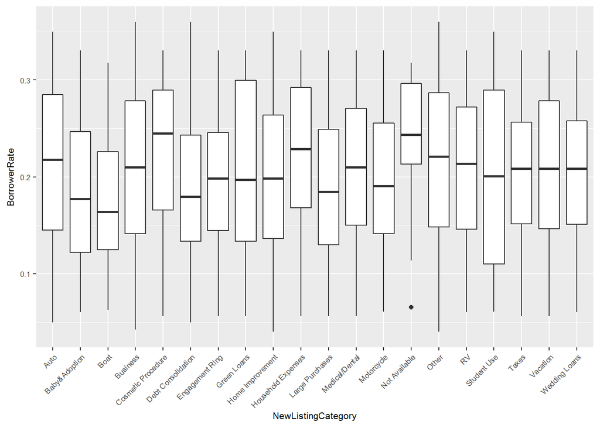

```
## # A tibble: 20 x 6
##    NewListingCategory     n  mean median `25%` `75%`
##    <chr>              <int> <dbl>  <dbl> <dbl> <dbl>
##  1 Not Available         20 0.239  0.243 0.213 0.296
##  2 Cosmetic Procedure    91 0.226  0.245 0.166 0.290
##  3 Household Expenses  1978 0.224  0.229 0.168 0.292
##  4 Other               9127 0.216  0.221 0.148 0.287
##  5 Auto                2229 0.214  0.218 0.145 0.285
##  6 Student Use          274 0.212  0.201 0.110 0.289
##  7 Business            5236 0.210  0.210 0.141 0.279
##  8 Medical/Dental      1493 0.210  0.210 0.150 0.270
##  9 Vacation             760 0.208  0.208 0.146 0.279
## 10 RV                    52 0.207  0.214 0.146 0.272
## 11 Taxes                879 0.207  0.208 0.151 0.257
## 12 Wedding Loans        753 0.206  0.208 0.151 0.258
## 13 Green Loans           57 0.204  0.197 0.133 0.300
## 14 Home Improvement    6713 0.201  0.198 0.136 0.264
## 15 Motorcycle           304 0.198  0.191 0.141 0.256
## 16 Engagement Ring      211 0.196  0.198 0.144 0.246
## 17 Large Purchases      851 0.192  0.184 0.130 0.249
## 18 Debt Consolidation 51849 0.188  0.180 0.133 0.243
## 19 Baby&Adoption        193 0.187  0.177 0.122 0.247
## 20 Boat                  85 0.174  0.164 0.125 0.226
```

Looking at the output above, we notice that the category *Not Available* has the highest average interest rate of (23.9%), unfortunately, that doesn’t tell us much information; but the interesting thing is the category *Cosmetic Procedure* which has a mean of (22.6%); this gives an idea of how these procedures are increasinlgy becoming a priority in peoples’ lives over other necessities, such as education, health, or business projects.

#### 3. Interest Rate vs Employement Status

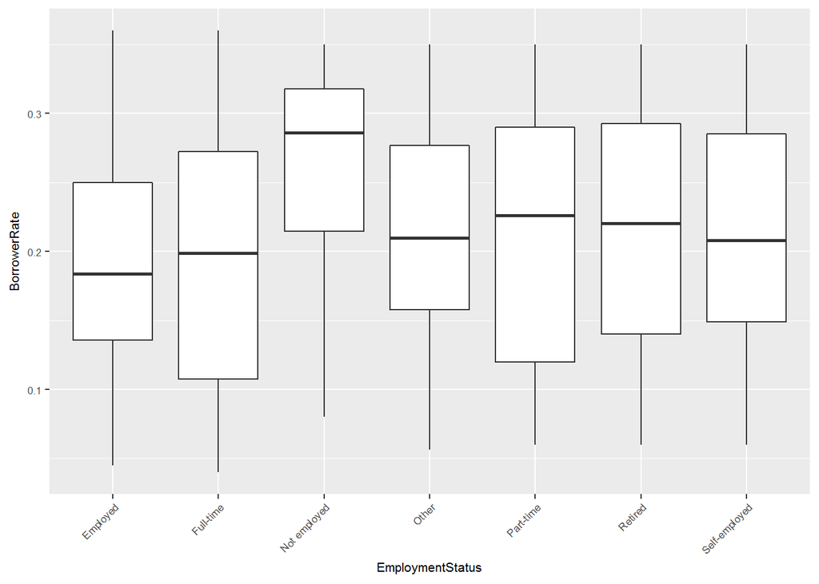

```
## # A tibble: 7 x 6
##   EmploymentStatus     n  mean median `25%` `75%`
##   <fct>            <int> <dbl>  <dbl> <dbl> <dbl>
## 1 Not employed       649 0.261  0.286 0.215 0.318
## 2 Retired            367 0.217  0.220 0.140 0.293
## 3 Other             3681 0.215  0.210 0.158 0.277
## 4 Self-employed     4377 0.213  0.208 0.149 0.285
## 5 Part-time          256 0.213  0.226 0.120 0.290
## 6 Full-time         7925 0.199  0.199 0.107 0.272
## 7 Employed         65900 0.193  0.184 0.136 0.250
```

Looking at the output above, we notice the category *Not employed* has the highest average interest rate of 26%, where the category *Employed* has the lowest average interest rate of 19.3%, which is expected.

#### 4. Interest Rate vs LoanOriginalAmount

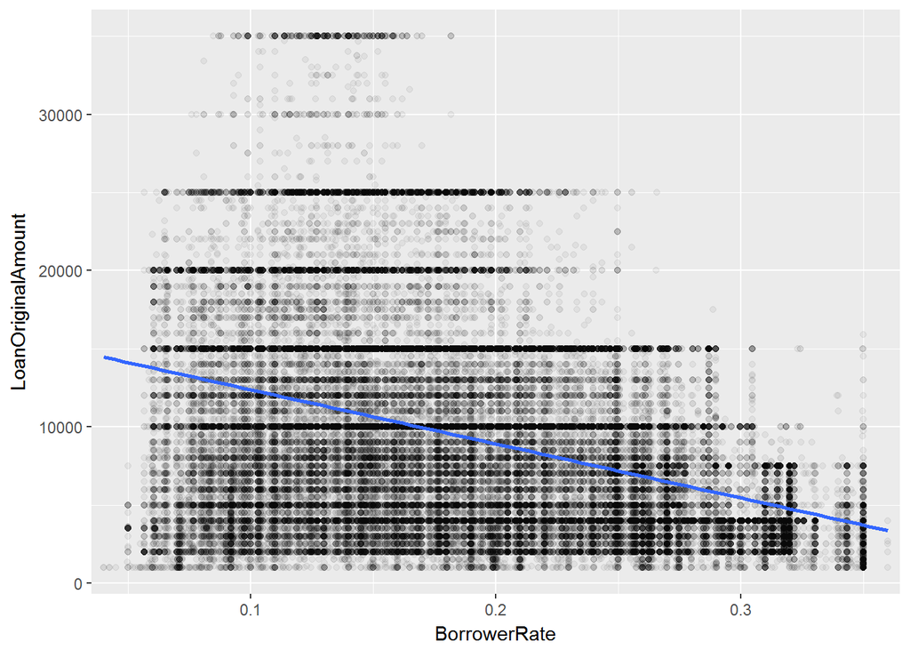

```
##
##  Pearson's product-moment correlation
##
## data:  loan_updated$LoanOriginalAmount and loan_updated$BorrowerRate
## t = -131.03, df = 83153, p-value < 0.00000000000000022
## alternative hypothesis: true correlation is not equal to 0
## 95 percent confidence interval:
##  -0.4193118 -0.4080445
## sample estimates:
##       cor
## -0.413694
```